# PS 3

```python
import numpy as np
import matplotlib.pyplot as plt
import seaborn as sns
import pandas as pd
import math
```

## 1. Binomial Distribution

#### 1.1. What is the expected value of this RV E X?

```python
S = 3
p = 0.6
EX = 0.6 + 0.6 + 0.6
print(EX)
```

```
1.7999999999999998
```

The expected value is 1.8

#### 1.2. What is the probability your get 0, 1, 2 or 3 “successes”?

First we find the P(single scenario) using the formula: $$ p^k (1-p)^{n-k} $$

```python
# 3 Successes
p_3suc = (p**3)*(0.4**(S-3))
# 2 Successes
p_2suc = (p**2)*(0.4**(S-2))
# 1 Success
p_1suc = (p**1)*(0.4**(S-1))
# 0 Success
p_0suc = (p**0)*(0.4**(S-0))
print("3 Successes: " + str(p_3suc))
print("2 Successes: " + str(p_2suc))
print("1 Successes: " + str(p_1suc))
print("0 Successes: " + str(p_0suc))
```

```
3 Successes: 0.21599999999999997
2 Successes: 0.144
1 Successes: 0.09600000000000002
0 Successes: 0.06400000000000002
```

Then we find the number of possible scenarios for each success case using the formula: $$ \frac{n!}{k!(n-k!)} $$

```python
n_fac = np.math.factorial(3)
s_3suc = n_fac/((3*2*1)*(1))
s_2suc = n_fac/((2*1)*(1))
s_1suc = n_fac/((1)*(2*1))
s_0suc = n_fac/((1)*(3*2*1))

print("3 Successes: " + str(s_3suc))
print("2 Successes: " + str(s_2suc))
print("1 Successes: " + str(s_1suc))
print("0 Successes: " + str(s_0suc))
```

```
3 Successes: 1.0
2 Successes: 3.0
1 Successes: 3.0
0 Successes: 1.0
```

Finally we multiply the P(Single Scenario) by the number of scenarios to get the probability of each number of success.

```python
prob_3suc = p_3suc * s_3suc
prob_2suc = p_2suc * s_2suc
prob_1suc = p_1suc * s_1suc
prob_0suc = p_0suc * s_0suc

print("3 Successes: " + str(prob_3suc * 100) + "%")
print("2 Successes: " + str(prob_2suc * 100) + "%")
print("1 Successes: " + str(prob_1suc * 100) + "%")
print("0 Successes: " + str(prob_0suc * 100) + "%")
```

```
3 Successes: 21.599999999999998%
2 Successes: 43.199999999999996%
1 Successes: 28.800000000000004%
0 Successes: 6.400000000000001%
```

#### 1.3. What is variance of this RV Var X?

Variance is found using the formula: $$np(1-p)$$ where n is sample size and p is success rate

```python
variance = S * p * (1-p)
print(variance)
```

```
0.72
```

#### 1.4. Now pick a sample size R (1000...100,000 are good numbers) and create a sample of size R of such random values.

```python
sample = np.random.binomial(3, 0.6, size=1000)
print(sample)
```

[output not shown]

#### 1.5. Compute the mean of your sample.

```python
sample_mean = np.mean(sample)
print("Mean: " + str(sample_mean))
```

```
Mean: 1.802
```

#### 1.6. Compute the variance of your sample.

```python
sample_v = sum(np.power(np.subtract(sample, sample_mean),2))/999
print("Sample Variance: " + str(sample_v))
```

```
Sample Variance: 0.7055015015015055
```

#### 1.7. Given your sample size, what are the expected number of cases with 0, 1, 2, and 3 successes?

```python
n_3suc = prob_3suc * 1000
n_2suc = prob_2suc * 1000
n_1suc = prob_1suc * 1000
n_0suc = prob_0suc * 1000

print("3 Successes: " + str(n_3suc) + " cases")
print("2 Successes: " + str(n_2suc) + " cases")
print("1 Successes: " + str(n_1suc) + " cases")
print("0 Successes: " + str(n_0suc) + " cases")
```

```
3 Successes: 215.99999999999997 cases
2 Successes: 431.99999999999994 cases
1 Successes: 288.00000000000006 cases
0 Successes: 64.00000000000001 cases
```

#### 1.8. Make a histogram of your sample. Add the expected number of cases to your histogram.

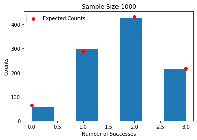

```python
plt.scatter([0, 1, 2, 3], [n_0suc, n_1suc, n_2suc, n_3suc], c="red", zorder=2)
plt.hist(sample, bins=7, edgecolor="w", zorder=1)
plt.title("Sample Size 1000")
plt.xlabel("Number of Successes")
plt.ylabel("Counts")
plt.legend(["Expected Counts"])
```

The histogram matches pretty well with the expected values, there wasn't any extreme differences between the histogram and the expected values that could be observed.

## 2. Log-normal Distribution

#### 2.1. Choose your sample size S. 10,000 is a good number.

```python
S_lnd = 10000
```

#### 2.2. Explore the shape of the distribution: draw S random numbers from LN(0, 0.2) (i.e. μ = 0 and σ = 0.2), LN(0, 0.5) and LN(0, 1.68). Display all these samples on a histogram while labeling clearly which one is which one. Do the histograms in two ways: a) linear-linear scale, and b) log-linear (x is log and y is linear). You can just do histogram of log x instead of x (you can also set log scale in matplotlib, but the bin widths will look weird). Comment the shape of histograms: do they look skewed? Do they look normal?

```python
mu = 0
sigma_1 = 0.2
sigma_2 = 0.5
sigma_3 = 1.68
sample_sigma1 = np.random.lognormal(mu, sigma_1, size = S_lnd)
sample_sigma2 = np.random.lognormal(mu, sigma_2, size = S_lnd)
sample_sigma3 = np.random.lognormal(mu, sigma_3, size = S_lnd)
```

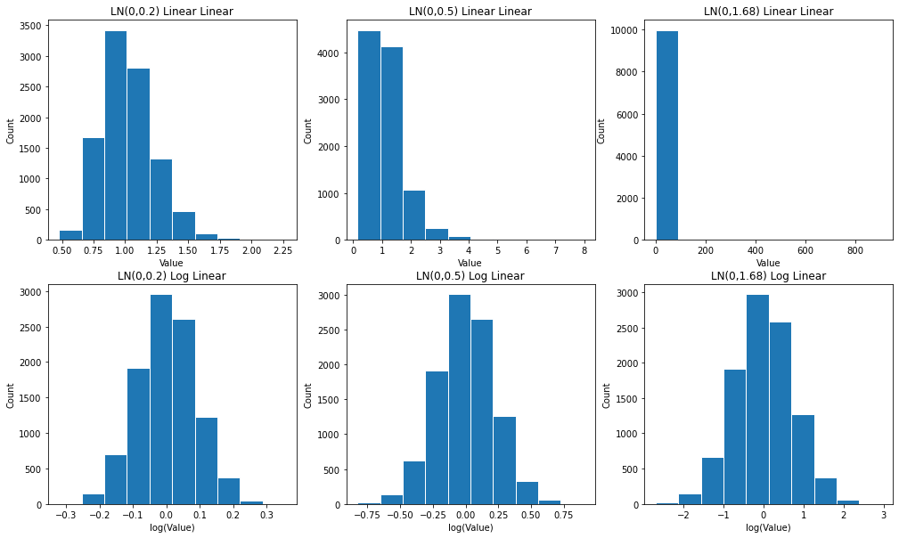

```python
plt.rcParams["figure.figsize"] = [17,10]

plt.subplot(2,3,1)
plt_sigma1 = plt.hist(sample_sigma1, edgecolor="w")
plt_sigma1 = plt.title("LN(0,0.2) Linear Linear")
plt_sigma1 = plt.xlabel("Value")
plt_sigma1 = plt.ylabel("Count")

plt.subplot(2,3,2)
plt_sigma2 = plt.hist(sample_sigma2, edgecolor="w")
plt_sigma2 = plt.title("LN(0,0.5) Linear Linear")
plt_sigma2 = plt.xlabel("Value")
plt_sigma2 = plt.ylabel("Count")

plt.subplot(2,3,3)
plt_sigma3 = plt.hist(sample_sigma3, edgecolor="w")
plt_sigma3 = plt.title("LN(0,1.68) Linear Linear")
plt_sigma3 = plt.xlabel("Value")
plt_sigma3 = plt.ylabel("Count")

plt.subplot(2,3,4)
plt_sigma1 = plt.hist(np.log10(sample_sigma1), edgecolor="w")
plt_sigma1 = plt.title("LN(0,0.2) Log Linear")
plt_sigma1 = plt.xlabel("log(Value)")
plt_sigma1 = plt.ylabel("Count")

plt.subplot(2,3,5)
plt_sigma2 = plt.hist(np.log10(sample_sigma2), edgecolor="w")
plt_sigma2 = plt.title("LN(0,0.5) Log Linear")
plt_sigma2 = plt.xlabel("log(Value)")
plt_sigma2 = plt.ylabel("Count")

plt.subplot(2,3,6)
plt_sigma3 = plt.hist(np.log10(sample_sigma3), edgecolor="w")
plt_sigma3 = plt.title("LN(0,1.68) Log Linear")
plt_sigma3 = plt.xlabel("log(Value)")
plt_sigma3 = plt.ylabel("Count")
```

The shapes of the linear linear histograms are typically skewed right, especially the LN(0,1.68) histogram, which all of the data are in one bin. However, the shapes of the log linear histograms all resemble the symmetrical shape, also especially the log linear of the LN(0,1.68) histogram.

#### 2.4. Compute sample means and variance (just use np.mean and such functions), and compare those with what you get using the corresponding theoretical formulas (2) and (3). Are these similar?

```python
smean_sigma1 = np.mean(sample_sigma1)
smean_sigma2 = np.mean(sample_sigma2)
smean_sigma3 = np.mean(sample_sigma3)
print("Sample Mean (np.mean())")
print("Sigma 1: " + str(smean_sigma1))
print("Sigma 2: " + str(smean_sigma2))
print("Sigma 3: " + str(smean_sigma3))
print("\n")
svar_sigma1 = np.var(sample_sigma1)
svar_sigma2 = np.var(sample_sigma2)
svar_sigma3 = np.var(sample_sigma3)
print("Variance (np.var())")
print("Sigma 1: " + str(svar_sigma1))
print("Sigma 2: " + str(svar_sigma2))
print("Sigma 3: " + str(svar_sigma3))
```

```
Sample Mean (np.mean())
Sigma 1: 1.02343699373861
Sigma 2: 1.13554652624661
Sigma 3: 4.2616854270708595


Variance (np.var())
Sigma 1: 0.04373302202710488
Sigma 2: 0.3809895640920754
Sigma 3: 278.92339296503246
```

Using the formulas: Expected Values: $$EX = e^{u+\frac{1}{2}o^2}$$ Variance: $$VarX = e^{2u+o^2}(e^{o^2}-1)$$

```python
ev_sigma1 = math.e**(mu + ((sigma_1**2)/2))
ev_sigma2 = math.e**(mu + ((sigma_2**2)/2))
ev_sigma3 = math.e**(mu + ((sigma_3**2)/2))
print("Theoretical Mean")
print("Sigma 1: " + str(ev_sigma1))
print("Sigma 2: " + str(ev_sigma2))
print("Sigma 3: " + str(ev_sigma3))
print("\n")
print("Theoretical Variance")
tv_sigma1 = (math.e**((2*mu) + (sigma_1**2))) * (math.e**(sigma_1-1**2) - 1)
tv_sigma2 = (math.e**((2*mu) + (sigma_2**2))) * (math.e**(sigma_2-1**2) - 1)
tv_sigma3 = (math.e**((2*mu) + (sigma_3**2))) * (math.e**(sigma_3-1**2) - 1)
print("Sigma 1: " + str(tv_sigma1))
print("Sigma 2: " + str(tv_sigma2))
print("Sigma 3: " + str(tv_sigma3))
```

```
Theoretical Mean
Sigma 1: 1.0202013400267558
Sigma 2: 1.1331484530668263
Sigma 3: 4.1008735008239405


Theoretical Variance
Sigma 1: -0.573144347182479
Sigma 2: -0.5052246336163366
Sigma 3: 16.377861022478598
```

#### 2.5. Compute the Pareto ratio of all three samples. (This is the same Pareto ratio you did in PS2 3.6, you can copy-paste code from there). Comment the results. Which distribution is the most unequal one? Which one the most equal one? Does this corresponds to what did you guessed based on the the histograms?

```python
def pareto(data):
    total = np.sum(data)
    threshold = np.percentile(data, 80)
    top20 = np.sum(data[data > threshold])
    share = top20/total
    return share/(1-share)
```

```python
pareto_sigma1 = pareto(sample_sigma1)
pareto_sigma2 = pareto(sample_sigma2)
pareto_sigma3 = pareto(sample_sigma3)
print("Sigma 1: " + str(pareto_sigma1))
print("Sigma 2: " + str(pareto_sigma2))
print("Sigma 3: " + str(pareto_sigma3))
```

```
Sigma 1: 0.3537064363021543
Sigma 2: 0.5846073541637251
Sigma 3: 4.144219675522543
```

## 3. Inequality In Data

#### 3.1. Load both datasets and do basic checks—do the values of interest (number of citations and income) look reasonable?

```python
treatment = pd.read_csv('treatment.csv.bz2', sep="\t")
income = treatment.re78
print(income.sample(10))
mag = pd.read_csv('mag-30k-citations.csv.bz2', sep="\t")
citations = mag.citations
print(citations.sample(10))
```

```
1564    23269.80
200      1152.63
1048    39817.30
1362    26599.10
854         0.00
2401    14777.30
434     25860.20
10          0.00
1968        0.00
2076    36943.20
Name: re78, dtype: float64
22052     12
26787      0
2465       1
25232     51
18205     37
17013    129
29399      0
20560      0
21171      2
6418       1
Name: citations, dtype: int64
```

The values look fine and reasonable

#### 3.2. Show the distribution of income and citations on a histogram. As the histogram may not look good, do it in two ways: a) histogram of income/citations and b) histogram of log income/citations. In order to avoid issues with log of zero you can do log(1 + income) instead of log income.

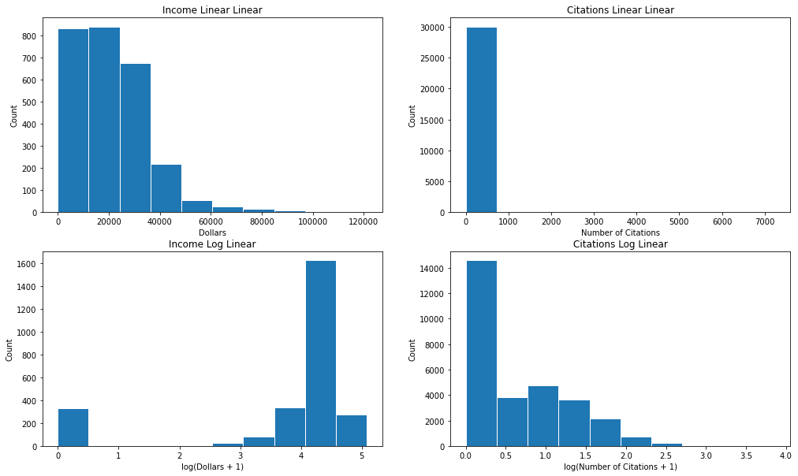

```python
plt.rcParams["figure.figsize"] = [17,10]

plt.subplot(2,2,1)
plt.hist(income, edgecolor="w")
plt.title("Income Linear Linear")
plt.xlabel("Dollars")
plt.ylabel("Count")

plt.subplot(2,2,2)
plt.hist(citations, edgecolor="w")
plt.title("Citations Linear Linear")
plt.xlabel("Number of Citations")
plt.ylabel("Count")

plt.subplot(2,2,3)
plt.hist(np.log10(np.add(income, 1)), edgecolor="w")
plt.title("Income Log Linear")
plt.xlabel("log(Dollars + 1)")
plt.ylabel("Count")

plt.subplot(2,2,4)
plt_sigma1 = plt.hist(np.log10(np.add(citations, 1)), edgecolor="w")
plt_sigma1 = plt.title("Citations Log Linear")
plt.xlabel("log(Number of Citations + 1)")
plt.ylabel("Count")
```

#### 3.3. Compute sample mean and standard deviation for both datasets. Compare these: how much smaller (or larger) is std. dev compared to the mean?

```python
income_mean = np.mean(income)
citations_mean = np.mean(citations)
print("Sample Mean (np.mean())")
print("Income: " + str(income_mean))
print("Citation: " + str(citations_mean))
print("\n")
income_standev = np.std(income)
citations_standev = np.std(citations)
print("Standard Deviation (np.std())")
print("Income: " + str(income_standev))
print("Citation: " + str(citations_standev))
print("\n")
print("Ratio Mean:Standard Deviation")
print("Income: " + str(income_mean/income_standev))
print("Citations: " + str(citations_mean/citations_standev))
```

```
Sample Mean (np.mean())
Income: 20502.37607865417
Citation: 15.605633333333333


Standard Deviation (np.std())
Income: 15629.597534767552
Citation: 79.1767834759606


Ratio Mean:Standard Deviation
Income: 1.311766092060098
Citations: 0.19709860199197743
```

#### 3.4. Compute the Pareto ratio for both distributions.

```python
pareto_income = pareto(income)
pareto_citations = pareto(citations)
print("Income: "+ str(pareto_income))
print("Citations: " + str(pareto_citations))
```

```
Income: 0.6810398132391002
Citations: 6.15668709968357
```

The pareto value of the income is 0.681, which is low, below the 80/20 rule and the pareto value of the citations is 6, which is pretty high, over the 80/20 rule.

## 4. Variance Of Mean

#### 4.1. Pick your number of repetitions R (1000...100,000 are good numbers).

```python
R = 10000
```

#### 4.2. Now do R times in a loop: create a single realization of this RV. Store all these in a vector (list or np array). You should have a vector of R realizations.

```python
sample_single = []
for i in range(10000):
    sample_single.append(np.random.binomial(3, 0.6, size=1))
```

#### 4.3. Compute variance of your sample.

```python
single_var = np.var(sample_single)
print("Variance (Single Realization): " + str(single_var))
```

```
Variance (Single Realization): 0.72038751
```

#### 4.4. Now do a loop of R again, but this time create a pair of realizations (S = 2). Compute the pair mean, and store it in a vector. You should have R pair means.

```python
sample_pair = []
mean_pair = []
for i in range(10000):
    pair = np.random.binomial(3, 0.6, size=2)
    sample_pair.append(pair)
    mean_pair.append(np.mean(pair))
```

#### 4.5. Compute variance of your pair means.

```python
pair_var = np.var(mean_pair)
print("Variance (Pair Realization): " + str(pair_var))
```

```
Variance (Pair Realization): 0.36115259750000006
```

#### 4.6. Repeat with S = 10-tuples (each time create 10 realizations in the loop and compute mean) and with S = 100-tuples. In both cases compute variance.

```python
sample_10 = []
sample_100 = []
mean_10 = []
mean_100 = []
for i in range(10000):
    realization10 = np.random.binomial(3, 0.6, size=10)
    realization100 = np.random.binomial(3, 0.6, size=100)
    sample_10.append(realization10)
    sample_100.append(realization100)
    mean_10.append(np.mean(realization10))
    mean_100.append(np.mean(realization100))

var_10 = np.var(mean_10)
var_100 = np.var(mean_100)
print("Variance (10 Realization): " + str(var_10))
print("Variance (100 Realization): " + str(var_100))
```

```
Variance (10 Realization): 0.0705219431
Variance (100 Realization): 0.007346659478999999
```

#### 4.7. Explain why variance of mean gets smaller when sample size S gets larger.

Variance of mean gets smaller when sample size gets larger is because a larger amount of data yields a more accurate result for example, when only doing single realization or double realizations, we can only get one or two possible results out of the 4 possible results (Successes: 0, 1, 2, 3), but if we increase the sample size to 10, or 100, we will have a higher chance that our data will cover all 4 possible results, which reduces the uncertainty, hence variance of mean gets smaller.